# Confidence Intervals

Dr. Lucy D’Agostino McGowan

# Confidence Intervals for Individual Coefficients

## The Basic Formula

**For coefficient $\beta_j$:**
$$\hat{\beta}_j \pm t_{\alpha/2, n-p} \times \text{se}(\hat{\beta}_j)$$

**Where:**  
- $t_{\alpha/2, n-p}$ is the critical value from t-distribution  
- $\text{se}(\hat{\beta}_j)$ is the standard error  
- $n - p$ are the degrees of freedom

## Where Does This Come From?

$\hat{\boldsymbol{\beta}} \sim N(\boldsymbol{\beta}, \sigma^2(\mathbf{X}^T\mathbf{X})^{-1})$

**For individual coefficient:**
$$\hat{\beta}_j \sim N(\beta_j, \sigma^2[(\mathbf{X}^T\mathbf{X})^{-1}]_{jj})$$

## Where Does This Come From?

$\hat{\boldsymbol{\beta}} \sim N(\boldsymbol{\beta}, \sigma^2(\mathbf{X}^T\mathbf{X})^{-1})$

**Standardize:**
$$\frac{\hat{\beta}_j - \beta_j}{\sigma\sqrt{[(\mathbf{X}^T\mathbf{X})^{-1}]_{jj}}} \sim N(0, 1)$$

## The t-Distribution Connection

**Problem:** We don’t know $\sigma$, so we estimate it with $\hat{\sigma}$

**Result:** Replace $\sigma$ with $\hat{\sigma}$ and the distribution changes
$$\frac{\hat{\beta}_j - \beta_j}{\hat{\sigma}\sqrt{[(\mathbf{X}^T\mathbf{X})^{-1}]_{jj}}} \sim t_{n-p}$$

## Standard Error Calculation

$$\text{se}(\hat{\beta}_j) = \hat{\sigma}\sqrt{[(\mathbf{X}^T\mathbf{X})^{-1}]_{jj}}$$

**Where:**  
- $\hat{\sigma}^2 = \frac{\text{SSE}}{n-p}$ (MSE)  
- $[(\mathbf{X}^T\mathbf{X})^{-1}]_{jj}$ is the $j$-th diagonal element

## You Try: Calculate Standard Error

**Given:**
$$(\mathbf{X}^T\mathbf{X})^{-1} = \begin{bmatrix} 0.25 & -0.10 \\ -0.10 & 0.05 \end{bmatrix}$$
$$\hat{\sigma}^2 = 16$$

**Find:** $\text{se}(\hat{\beta}_1)$

`02:00`

## Constructing the 95% CI

**Formula:**
$$\text{CI}_{95\%} = \hat{\beta}_j \pm t_{0.025, n-p} \times \text{se}(\hat{\beta}_j)$$

## Example: CI Calculation

**Given:** $\hat{\beta}_1 = 3.2$, $\text{se}(\hat{\beta}_1) = 0.8$, $n = 30$, $p = 3$

**Step 1:** Find critical value  
$t_{0.025, 27} = 2.052$ (`qt(0.975, 27)`)

**Step 2:** Construct interval
$$\text{CI}_{95\%} = [3.2 - 2.052\times0.8, 3.2 + 2.052\times0.8] = [1.6, 4.8]$$

## Interpreting Confidence Intervals

**What this means:**  
If we repeated this procedure many times with different samples from the same population, 95% of the intervals would contain the true $\beta_1$

**What we CANNOT say:**  
“There is a 95% probability that $\beta_1$ is in this interval”  
(The parameter is fixed!)

# DEMO

## You Try: Build a Confidence Interval

**Given:**  
- $\hat{\beta}_2 = 5.6$  
- $\text{se}(\hat{\beta}_2) = 1.2$  
- $n = 25$, $p = 4$  
- $t_{0.025, 21} = 2.08$

**Find:** 95% confidence interval for $\hat\beta_2$

`03:00`

# Computing CIs in R

## Let’s do it in R

```r
x <- c(1, 2, 3, 4, 5)
y <- c(2.1, 3.9, 6.2, 7.8, 10.1)
model <- lm(y ~ x)

confint(model)
```

```
                 2.5 %    97.5 %
(Intercept) -0.5803601 0.6803601
x            1.7999393 2.1800607
```

```r
# 90% confidence intervals
confint(model, level = 0.90)
```

```
                   5 %      95 %
(Intercept) -0.4161403 0.5161403
x            1.8494534 2.1305466
```

## Manual Calculation in R

```r
beta_hat <- coef(model)
se_beta <- summary(model)$coefficients[, "Std. Error"]
n <- length(y)
p <- length(beta_hat)
df <- n - p

t_crit <- qt(0.975, df)

lower <- beta_hat - t_crit * se_beta
upper <- beta_hat + t_crit * se_beta

cbind(lower, upper)
```

```
                 lower     upper
(Intercept) -0.5803601 0.6803601
x            1.7999393 2.1800607
```

## Your turn

Using the data below fit a model and get 99% confidence intervals.

```r
# Data
x1 <- c(1, 2, 3, 4, 5, 6)
x2 <- c(2, 3, 3, 5, 6, 7)
y <- c(3, 5, 6, 8, 10, 11)

# Your turn: fit model and get 99% CIs
```

`03:00`

# Bootstrap Confidence Intervals

## What is the Bootstrap?

We can use the data to understand its own variability

**How it works:**  
1. Resample your data (with replacement)  
2. Fit model to resampled data  
3. Record $\hat{\beta}$  
4. Repeat many times (typically 1000+)  
5. Use distribution of $\hat{\beta}$ values to build CI

## Types of Bootstrap CIs

**1. Percentile method** Take quantiles of bootstrap distribution

**2. Bootstrap t**  
Take the SE from bootstrap distribution and use a critical t-value to construct an interval

**3. Bias-corrected and accelerated (BCa)**  
Adjusts for bias and skewness (most accurate)

## Percentile Bootstrap Method

**Algorithm:**  
1. Generate B bootstrap samples (e.g., B = 1000)  
2. For each sample, compute $\hat{\beta}_j^{(b)}$  
3. Sort all B values  
4. Take 2.5th and 97.5th percentiles for 95% CI

**CI formula:**
$$\text{CI}_{95\%} = [Q_{0.025}, Q_{0.975}]$$
where $Q_\alpha$ is the $\alpha$-quantile of bootstrap distribution

## Bootstrap Algorithm Detail

**For each bootstrap iteration $b = 1, \ldots, B$:**

1. Resample indices: $i_1^{(b)}, \ldots, i_n^{(b)}$ from $\{1, \ldots, n\}$ with replacement
2. Create bootstrap sample: $\mathbf{y}^{(b)} = (y_{i_1^{(b)}}, \ldots, y_{i_n^{(b)}})^T$  
   $\mathbf{X}^{(b)} = (\mathbf{x}_{i_1^{(b)}}, \ldots, \mathbf{x}_{i_n^{(b)}})^T$
3. Fit model: $\hat{\boldsymbol{\beta}}^{(b)} = ((\mathbf{X}^{(b)})^T\mathbf{X}^{(b)})^{-1}(\mathbf{X}^{(b)})^T\mathbf{y}^{(b)}$

## Implementing Bootstrap in R

```r
set.seed(1)
x <- 1:20
y <- 2 + 3*x + rnorm(20, 0, 5)
data <- data.frame(x, y)

model <- lm(y ~ x, data)
beta_hat <- coef(model)

B <- 1000

bootstrap_one <- function(data) {
  boot_data <- data[sample(1:nrow(data), replace = TRUE), ]
  boot_model <- lm(y ~ x, data = boot_data)
  boot_beta_hat <- coef(boot_model)
  return(boot_beta_hat)
}

boot_betas <- purrr::map_df(1:B, ~bootstrap_one(data))
boot_betas
```

```
# A tibble: 1,000 × 2
   `(Intercept)`     x
           <dbl> <dbl>
 1        -2.01   3.28
 2         2.64   3.02
 3         0.256  3.27
 4        -0.131  3.08
 5         2.07   3.17
 6         1.60   3.11
 7         0.584  3.18
 8         4.55   2.80
 9         4.14   2.86
10         2.25   3.01
# ℹ 990 more rows
```

## Bootstrap CIs

```r
boot_ci_intercept <- quantile(boot_betas$`(Intercept)`, c(0.025, 0.975))
boot_ci_slope <- quantile(boot_betas$x, c(0.025, 0.975))

cat("Bootstrap CI for intercept:", round(boot_ci_intercept, 3), "\n")
```

```
Bootstrap CI for intercept: -1.261 5.968
```

```r
cat("Bootstrap CI for slope:", round(boot_ci_slope, 3), "\n")
```

```
Bootstrap CI for slope: 2.755 3.351
```

```r
# Compare to traditional CI
confint(model)
```

```
                2.5 %   97.5 %
(Intercept) -2.714035 6.353106
x            2.729458 3.486368
```

## Visualizing Bootstrap Distribution

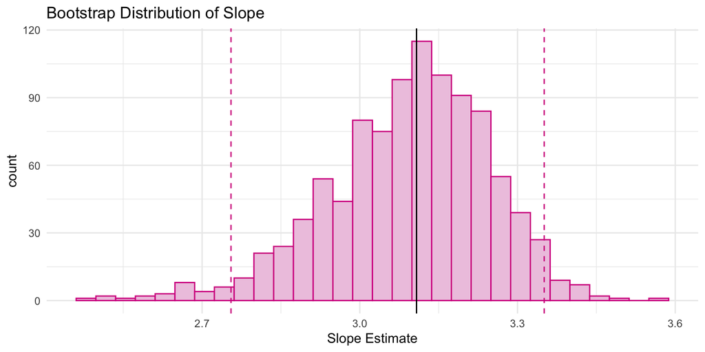

## Your Turn

Compute a bootstrap 90% CI for the slope

```r
# Use this data
x <- c(1, 2, 3, 4, 5, 6, 7, 8)
y <- c(2.1, 3.8, 6.2, 7.9, 9.8, 12.1, 14.3, 15.8)
```

`05:00`

# Coverage Probability

## What is Coverage?

**Definition:** The proportion of confidence intervals that contain the true parameter

**Ideal coverage:** Should match confidence level  
- 95% CI should have 95% coverage  
- 90% CI should have 90% coverage

**In practice:** Coverage can be lower due to:  
- Violated assumptions  
- Small sample sizes  
- Model misspecification

## Checking Coverage via Simulation

**The procedure:**  
1. Choose true parameter values  
2. Generate data from the model  
3. Compute confidence interval  
4. Check if true value is inside  
5. Repeat many times  
6. Calculate proportion containing truth

## Coverage Simulation Example

```r
set.seed(1)
n_sims <- 1000

sim <- function(true_beta0 = 2, true_beta1 = 1, sigma = 5, n = 30) {
  # Generate data
  x <- runif(n, 0, 10)
  y <- true_beta0 + true_beta1 * x + rnorm(n, 0, sigma)

  # Fit model and get CI
  model <- lm(y ~ x)
  ci <- confint(model, level = 0.95)[2, ]  # CI for slope

  # Check coverage
  ci[1] <= true_beta1 && true_beta1 <= ci[2]
}

coverage <- purrr::map_lgl(1:n_sims, ~sim())
mean(coverage)
```

```
[1] 0.957
```

## Interpreting Coverage Results

**Our result:** ~95% coverage (as expected!)

**If coverage is too low (<95%):**  
- Standard errors may be underestimated  
- Assumptions may be violated  
- Consider robust methods or bootstrap

**If coverage is too high (>95%):**  
- CIs are conservative (too wide)  
- Losing power  
- May be okay, but inefficient